# 6_1_BenchmarkModels_FittedValues_Forecasts

## Forecasts

```r
# produce forecasts for 8 timesteps
forecasts <- fit %>% forecast(h = 8)
forecasts
```

```
# A fable: 8 x 5 [1Y]
# Key:     Country, .model [1]
  Country   .model  Year    Exports .mean
  <fct>     <chr>  <dbl>     <dist> <dbl>
1 Australia Naive   2018 N(21, 1.5)  21.3
2 Australia Naive   2019 N(21, 3.1)  21.3
3 Australia Naive   2020 N(21, 4.6)  21.3
4 Australia Naive   2021 N(21, 6.1)  21.3
5 Australia Naive   2022 N(21, 7.6)  21.3
6 Australia Naive   2023 N(21, 9.2)  21.3
7 Australia Naive   2024  N(21, 11)  21.3
8 Australia Naive   2025  N(21, 12)  21.3
```

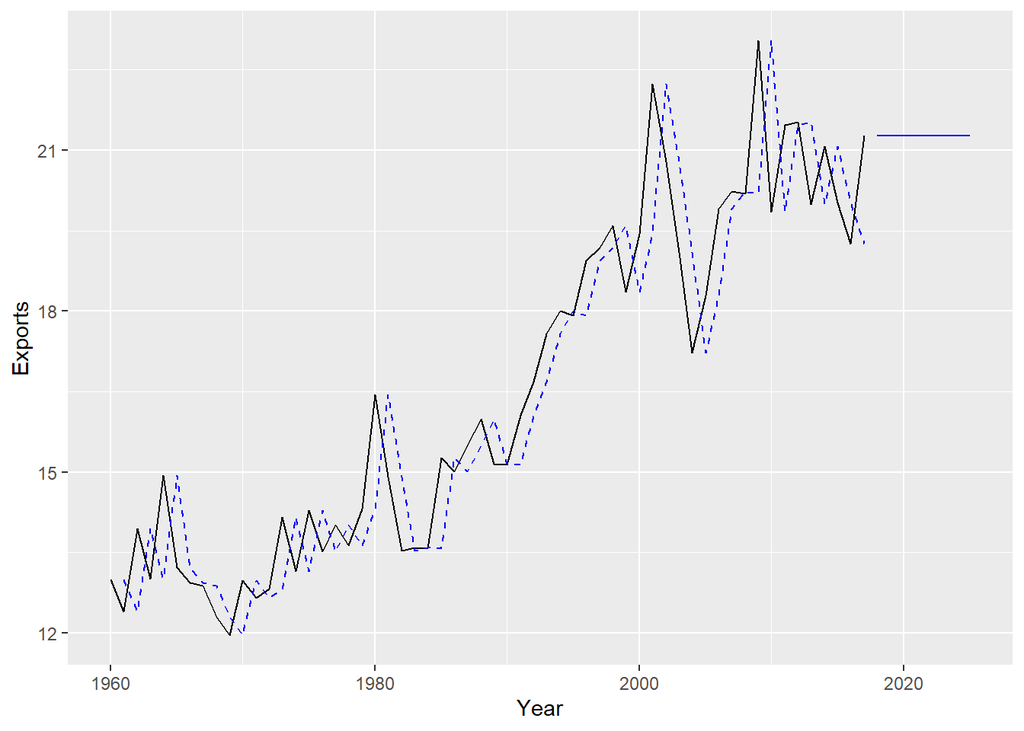

```r
# Depict the forecasts
forecasts %>%
  autoplot(aus_exports, level = FALSE) +

  # Overlays the fitted values
  geom_line(data = fitted_vals, aes(y = .fitted), colour = "blue", linetype = "dashed")
```

Unlike the fitted values, the forecasts can extend multiple steps ahead into the future.

## Number of parameters

```r
tidy(fit)
```

```
# A tibble: 0 × 7
# … with 7 variables: Country <fct>, .model <chr>, term <chr>, estimate <dbl>,
#   std.error <dbl>, statistic <dbl>, p.value <dbl>
```

As we can see, the Naïve model does not have any parameter. It just forecasts by extending the last observation.

# Residuals

The **residuals** are the **difference between the observations and the corresponding fitted values**

$$\begin{align*}
e_{t} = y_{t}-\hat{y}_{t}.
\end{align*}$$

- **Innovation residuals**: these are the residuals in the *transformed domain*, only relevant if a transformation has been used
  - For example, when using logarithms of the data $w_t = log(y_t)$, the innovation residuals are given by $w_t - \hat{w_t}$ and the regular residuals are given by $y_t - \hat{y_t}$.

As already shown in the previous notebooks, the residuals can be extracted from the fitted object model using the function `augment()`.

# Seasonal naïve

Each forecast equal to the last observed value from the same season (e.g. the same month of the previous year). Formally the *forecast at time T+h*:

$$\begin{align*}
\hat{y}_{T+h|T} = y_{T+h-m(k+1)}
\end{align*}$$

where:

- $m$ is the seasonal period
- $k$ is the integer part of $(h-1)/m$ (i.e, the number of complete years in the forecast period prior to time T + h)
  - **Example:** for monthly data ($m=12$)
    - $1 \leq h \leq 12$ (forecasts of up to one season ahead) - $0 \leq h-1/m \leq 1 \rightarrow k = 0$.
    - $13 \leq h \leq 24$ (forecasts of up to two sessions ahead) - $1 \leq h-1/m \leq 2\rightarrow k = 1$.
    - …

The interpretation of the formula is therefore quite simple: *future February values will be equal to the last observed February value*

Let us do an example with the us_employment series:

```r
employed <- filter(us_employment, Title == "Total Private", Month >= yearmonth("01-01-2010"))
head(employed)
```

```
# A tsibble: 6 x 4 [1M]
# Key:       Series_ID [1]
     Month Series_ID     Title         Employed
     <mth> <chr>         <chr>            <dbl>
1 2010 Jan CEU0500000001 Total Private   105444
2 2010 Feb CEU0500000001 Total Private   105490
3 2010 Mar CEU0500000001 Total Private   106176
4 2010 Apr CEU0500000001 Total Private   107220
5 2010 May CEU0500000001 Total Private   107931
6 2010 Jun CEU0500000001 Total Private   108710
```

```
Plot variable not specified, automatically selected `.vars = Employed`
```

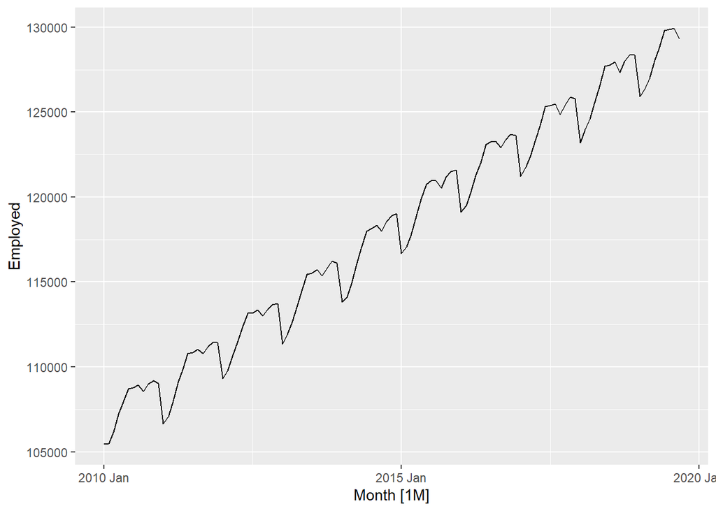

```r
autoplot(employed)
```

## Defining and training the model

**NOTE**: within the special function `lag()` we need to specify the length of the seasonality to be considered

```r
fit <- employed %>% model(SNaive = SNAIVE(Employed ~ lag("year")))
fit
```

```
# A mable: 1 x 2
# Key:     Series_ID [1]
  Series_ID       SNaive
  <chr>          <model>
1 CEU0500000001 <SNAIVE>
```

## Fitted values

Because the method generates forecasts by using the corresponding observation from the previous season, the model does not generate fitted values for the first season (remember fitted values are one-step ahead forecasts):

```r
# Extract fitted values and inspect table
fitted_vals <- fit %>% augment()
head(fitted_vals)
```

```
# A tsibble: 6 x 7 [1M]
# Key:       Series_ID, .model [1]
  Series_ID     .model    Month Employed .fitted .resid .innov
  <chr>         <chr>     <mth>    <dbl>   <dbl>  <dbl>  <dbl>
1 CEU0500000001 SNaive 2010 Jan   105444      NA     NA     NA
2 CEU0500000001 SNaive 2010 Feb   105490      NA     NA     NA
3 CEU0500000001 SNaive 2010 Mar   106176      NA     NA     NA
4 CEU0500000001 SNaive 2010 Apr   107220      NA     NA     NA
5 CEU0500000001 SNaive 2010 May   107931      NA     NA     NA
6 CEU0500000001 SNaive 2010 Jun   108710      NA     NA     NA
```

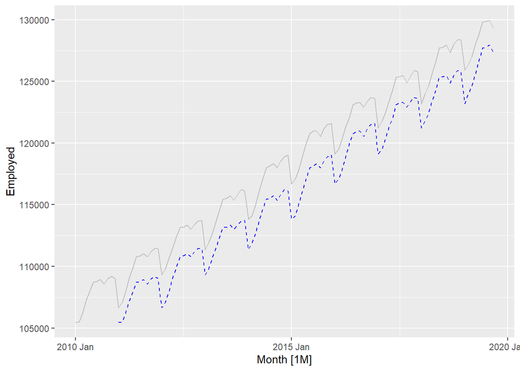

```r
# Print fitted values along with the original series
fitted_vals %>%
  filter(.model == "SNaive") %>%
  autoplot(Employed, colour = "gray") +
  geom_line(aes(y=.fitted), colour = "blue", linetype = "dashed")
```

## Forecasts

```r
# produce forecasts for 8 timesteps
forecasts <- fit %>% forecast(h = 36)
forecasts
```

```
# A fable: 36 x 5 [1M]
# Key:     Series_ID, .model [1]
   Series_ID     .model    Month           Employed  .mean
   <chr>         <chr>     <mth>             <dist>  <dbl>
 1 CEU0500000001 SNaive 2019 Oct N(128001, 5538565) 128001
 2 CEU0500000001 SNaive 2019 Nov N(128415, 5538565) 128415
 3 CEU0500000001 SNaive 2019 Dec N(128363, 5538565) 128363
 4 CEU0500000001 SNaive 2020 Jan N(125932, 5538565) 125932
 5 CEU0500000001 SNaive 2020 Feb N(126370, 5538565) 126370
 6 CEU0500000001 SNaive 2020 Mar N(126994, 5538565) 126994
 7 CEU0500000001 SNaive 2020 Apr N(128007, 5538565) 128007
 8 CEU0500000001 SNaive 2020 May N(128771, 5538565) 128771
 9 CEU0500000001 SNaive 2020 Jun N(129800, 5538565) 129800
10 CEU0500000001 SNaive 2020 Jul N(129883, 5538565) 129883
# … with 26 more rows
```

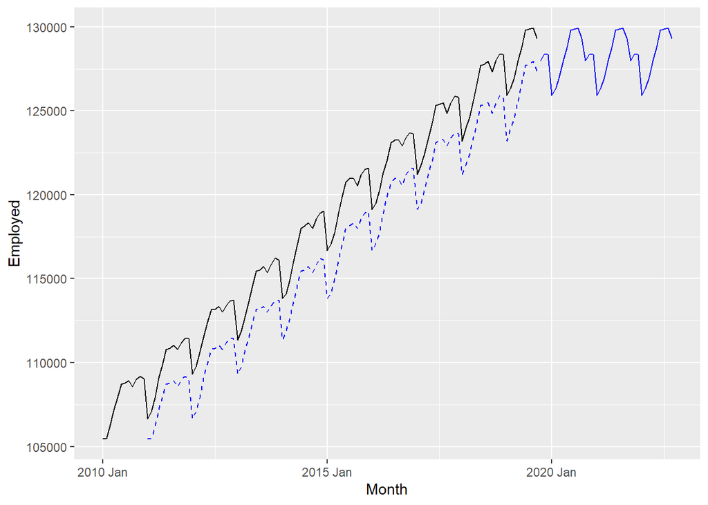

```r
# Depict the forecasts
forecasts %>%
  autoplot(employed, level = FALSE) +
  autolayer(fitted_vals, .fitted, colour = "blue", linetype = "dashed")
```

## Number of parameters

```r
tidy(fit)
```

```
# A tibble: 0 × 7
# … with 7 variables: Series_ID <chr>, .model <chr>, term <chr>,
#   estimate <dbl>, std.error <dbl>, statistic <dbl>, p.value <dbl>
```

As we can see, the seasonal naïve model, just like the naïve model, does not have any parameters

# Drift method

Variation of the naïve method. Allows forecasts to increase or decrease over time. **Drift** is the amount of change over time, set to be the **average change in the historical data**:

$$\begin{align*}
\hat{y}_{T+h|T} = y_{T} + \frac{h}{T-1}\sum_{t=2}^T (y_{t}-y_{t-1}) = y_{T} + h \left( \frac{y_{T} -y_{1}}{T-1}\right).
\end{align*}$$

## Defining and training the model

- NOTE: RW stands for *Random Walk*. More about this later in the subject (within ARIMA models).

```r
fit <- employed %>% model(Drift = RW(Employed ~ drift()))
fit
```

```
# A mable: 1 x 2
# Key:     Series_ID [1]
  Series_ID             Drift
  <chr>               <model>
1 CEU0500000001 <RW w/ drift>
```

**Equivalent to drawing a line between the first and last observations and extrapolating into the future** (the final graph of the example clarifies this further).

## Fitted values

```r
# Extract fitted values and inspect table
fitted_vals <- fit %>% augment()
head(fitted_vals)
```

```
# A tsibble: 6 x 7 [1M]
# Key:       Series_ID, .model [1]
  Series_ID     .model    Month Employed .fitted .resid .innov
  <chr>         <chr>     <mth>    <dbl>   <dbl>  <dbl>  <dbl>
1 CEU0500000001 Drift  2010 Jan   105444     NA     NA     NA
2 CEU0500000001 Drift  2010 Feb   105490 105650.  -160.  -160.
3 CEU0500000001 Drift  2010 Mar   106176 105696.   480.   480.
4 CEU0500000001 Drift  2010 Apr   107220 106382.   838.   838.
5 CEU0500000001 Drift  2010 May   107931 107426.   505.   505.
6 CEU0500000001 Drift  2010 Jun   108710 108137.   573.   573.
```

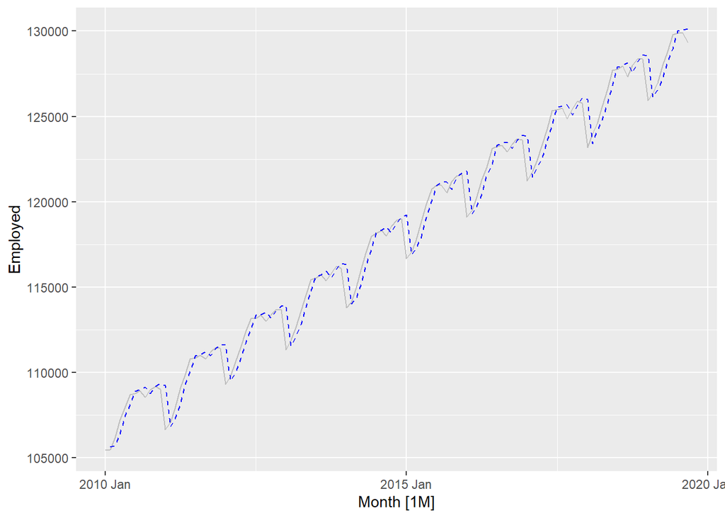

```r
# Print fitted values along with the original series
fitted_vals %>%
  filter(.model == "Drift") %>%
  autoplot(Employed, colour = "gray") +
  geom_line(aes(y=.fitted), colour = "blue", linetype = "dashed")
```

## Forecasts

```r
forecasts <- fit %>% forecast(h=8)
forecasts
```

```
# A fable: 8 x 5 [1M]
# Key:     Series_ID, .model [1]
  Series_ID     .model    Month           Employed   .mean
  <chr>         <chr>     <mth>             <dist>   <dbl>
1 CEU0500000001 Drift  2019 Oct  N(129518, 764786) 129518.
2 CEU0500000001 Drift  2019 Nov N(129724, 1542645) 129724.
3 CEU0500000001 Drift  2019 Dec N(129929, 2333578) 129929.
4 CEU0500000001 Drift  2020 Jan N(130135, 3137584) 130135.
5 CEU0500000001 Drift  2020 Feb   N(130341, 4e+06) 130341.
6 CEU0500000001 Drift  2020 Mar N(130547, 4784816) 130547.
7 CEU0500000001 Drift  2020 Apr N(130752, 5628041) 130752.
8 CEU0500000001 Drift  2020 May N(130958, 6484340) 130958.
```

```r
# Extract the initial and final points of the series
# to depict the average change slope.
n_rows = nrow(employed)
drift_points <- tibble(Month = c(employed$Month[1], employed$Month[n_rows]),
                       Employed = c(employed$Employed[1], employed$Employed[n_rows])) %>%
                as_tsibble()
```

```
Using `Month` as index variable.
```

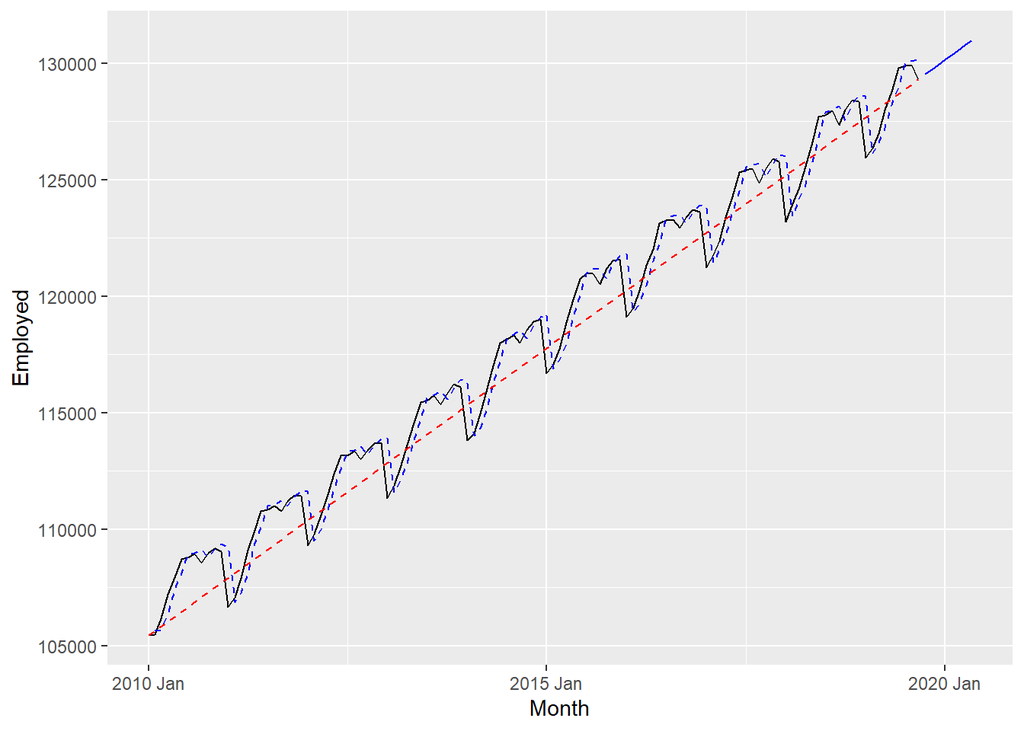

```r
# Depict the forecasts
forecasts %>%
  autoplot(employed, level = FALSE) +
  autolayer(fitted_vals, .fitted, colour = "blue", linetype = "dashed") +
  geom_line(drift_points, mapping = aes(x = Month, y = Employed), color = "red", linetype = "dashed")
```

In the above graph we can see that:

1. The forecasts are generated following the slope of the line that connects the initial and final points of the series (red slope). A further example is depicted in the image below:

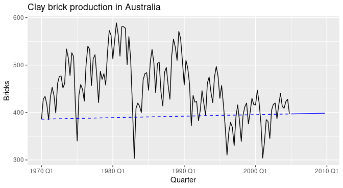

Further example of the drift method. From [1]

2. The fitted values are very similar to those of the Naïve Method. Nonetheless, they are not the same. In this case each fitted value is generated by a one-step forecast using the drift method. That is, following the slope resulting from connecting each point of the series with the initial point and extending it one step into the future.

## Number of parameters

We can look at the number of parameters in a model and their values using the function `tidy()`. If we apply it to the drift model we get:

```r
tidy(fit)
```

```
# A tibble: 1 × 7
  Series_ID     .model term  estimate std.error statistic p.value
  <chr>         <chr>  <chr>    <dbl>     <dbl>     <dbl>   <dbl>
1 CEU0500000001 Drift  b         206.      80.8      2.54  0.0123
```

The drift model has only one parameter, the slope of the line joining the first and the last observation.

# Forecasting with decomposition

Let:

- $\hat{A_t}$ be the seasonally adjusted component of a time series
- $\hat{S_t}$ be the seasonal component of a time series

The decomposed series can be written as:

- $y_t = \hat{S}_t + \hat{A}_t$ for additive schemes
  - where $\hat{A}_t = \hat{T}_t+\hat{R}_{t}$ is the seasonally adjusted component.
- $y_t = \hat{S}_t\hat{A}_t$ for multiplicative schemes
  - where $\hat{A}_t = \hat{T}_t\hat{R}_{t}$ is the seasonally adjusted component.

To forecast a decomposed time series $\hat{S_t}$ and $\hat{A_t}$ are forecast separately:

- $\hat{A_t}$: any non-seasonal forecasting method may be used (drift method, Holt’s method, ARIMA)…
- $\hat{S_t}$: usually assumed to remain unchanged, or changing very slowly. It is usually forecast by taking the observations of the last season, following the seasonal naïve.

## Fitting the model

Let us again resort to the `employed` time series:

```
Plot variable not specified, automatically selected `.vars = Employed`
```

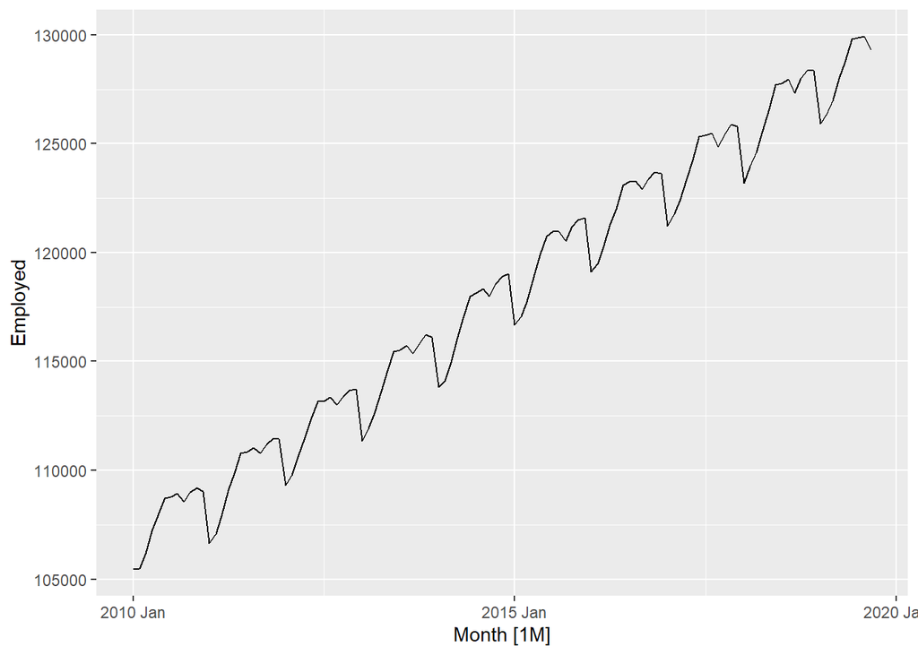

```r
employed <- filter(us_employment, Title == "Total Private", Month >= yearmonth("01-01-2010"))
autoplot(employed)
```

To fully understand the model specification, let us first look at the outcome of an STL decomposition applied to this series

```r
employed %>%
  model(
    stl = STL(Employed)
  ) %>%
  components()
```

```
# A dable: 117 x 8 [1M]
# Key:     Series_ID, .model [1]
# :        Employed = trend + season_year + remainder
   Series_ID     .model    Month Employed   trend season_year remainder season…¹
   <chr>         <chr>     <mth>    <dbl>   <dbl>       <dbl>     <dbl>    <dbl>
 1 CEU0500000001 stl    2010 Jan   105444 107188.      -2016.    272.    107460.
 2 CEU0500000001 stl    2010 Feb   105490 107314.      -1816.     -8.49  107306.
 3 CEU0500000001 stl    2010 Mar   106176 107440.      -1231.    -33.0   107407.
 4 CEU0500000001 stl    2010 Apr   107220 107566.       -361.     14.7   107581.
 5 CEU0500000001 stl    2010 May   107931 107695.        305.    -69.4   107626.
 6 CEU0500000001 stl    2010 Jun   108710 107825.       1006.   -121.    107704.
 7 CEU0500000001 stl    2010 Jul   108784 107954.        916.    -85.9   107868.
 8 CEU0500000001 stl    2010 Aug   108936 108087.        886.    -36.8   108050.
 9 CEU0500000001 stl    2010 Sep   108568 108220.        357.     -9.10  108211.
10 CEU0500000001 stl    2010 Oct   108984 108353.        648.    -17.2   108336.
# … with 107 more rows, and abbreviated variable name ¹season_adjust
```

The seasonal component is stored in a column named `season_year` and the seasonally adjusted component is stored in a column named `season_adjust`. To give a full specification to `decomposition_model()` we need to:

- Specify a decomposition scheme
- Provide a model for the seasonally adjusted component.
- Provide a model for the seasonal component (by default the SNAIVE component is used, so this is not strictly necessary).

```r
fit <- employed %>%
  model(
    decomp = decomposition_model(
                # Specify the decomposition scheme to be used.
                STL(Employed),
                # Specify a model for the seasonally adjusted component (in this case, a drift).
                RW(season_adjust ~ drift()),
                # Specify a model for the seasonal component (unnecesary, since SNAIVE is the default).
                SNAIVE(season_year)
            )
  )

fit
```

```
# A mable: 1 x 2
# Key:     Series_ID [1]
  Series_ID                        decomp
  <chr>                           <model>
1 CEU0500000001 <STL decomposition model>
```

## Fitted values

As usual, you can extract the fitted values using `augment()`:

```r
fit %>% augment()
```

```
# A tsibble: 117 x 7 [1M]
# Key:       Series_ID, .model [1]
   Series_ID     .model    Month Employed .fitted .resid .innov
   <chr>         <chr>     <mth>    <dbl>   <dbl>  <dbl>  <dbl>
 1 CEU0500000001 decomp 2010 Jan   105444      NA     NA     NA
 2 CEU0500000001 decomp 2010 Feb   105490      NA     NA     NA
 3 CEU0500000001 decomp 2010 Mar   106176      NA     NA     NA
 4 CEU0500000001 decomp 2010 Apr   107220      NA     NA     NA
 5 CEU0500000001 decomp 2010 May   107931      NA     NA     NA
 6 CEU0500000001 decomp 2010 Jun   108710      NA     NA     NA
 7 CEU0500000001 decomp 2010 Jul   108784      NA     NA     NA
 8 CEU0500000001 decomp 2010 Aug   108936      NA     NA     NA
 9 CEU0500000001 decomp 2010 Sep   108568      NA     NA     NA
10 CEU0500000001 decomp 2010 Oct   108984      NA     NA     NA
# … with 107 more rows
```

**QUESTION**: Why are the first rows of the fitted values NAs??

```r
Because the model combines a drift model with a seasonal naive model, it needs
a full season to go by before it can actually start producing forecasts.
Remember fitted values can be thought of as one-step ahead forecasts.
```

## Forecasts

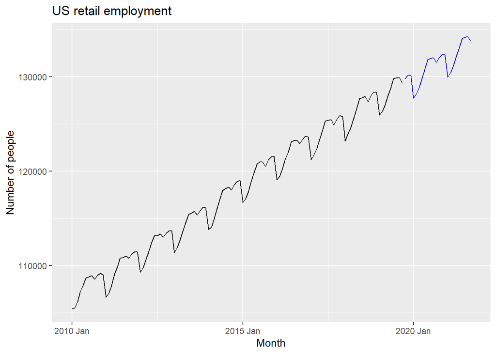

```r
fit %>%
  forecast() %>%
  autoplot(employed, level = FALSE) +
  labs(y = "Number of people",
       title = "US retail employment")
```

The graph above shows that the model combines the SNAIVE + the DRIFT forecasts (this is equivalent to adding the slope of the drift model to the seasonal naive model).

# Exercise 1

For this exercise we are going to use the `aus_retail` dataset. Remember you can always use `?aus_retail` in the console to red the details abut the dataset.

The dataset contains a variety of series that that might be filtered using their specific series ID. We will be working the the following Series ID: A3349767W. The following code filters the series for you.

```r
retail_series <- aus_retail %>%
  filter(`Series ID` == "A3349767W")

head(retail_series)
```

```
# A tsibble: 6 x 5 [1M]
# Key:       State, Industry [1]
  State              Industry                           Serie…¹    Month Turno…²
  <chr>              <chr>                              <chr>      <mth>   <dbl>
1 Northern Territory Clothing, footwear and personal a… A33497… 1988 Apr     2.3
2 Northern Territory Clothing, footwear and personal a… A33497… 1988 May     2.9
3 Northern Territory Clothing, footwear and personal a… A33497… 1988 Jun     2.6
4 Northern Territory Clothing, footwear and personal a… A33497… 1988 Jul     2.8
5 Northern Territory Clothing, footwear and personal a… A33497… 1988 Aug     2.9
6 Northern Territory Clothing, footwear and personal a… A33497… 1988 Sep     3
# … with abbreviated variable names ¹`Series ID`, ²Turnover
```